# Machine Learning con R y mlr3

# Modelos

En los siguientes apartados se entrenan diferentes modelos de *machine learning* con el objetivo de compararlos e identificar el que mejor resultado obtiene prediciendo el precio de las viviendas.

## GLM

Los modelos [GLM](https://es.wikipedia.org/wiki/Modelo_lineal_generalizado) (John Nelder y Robert Wedderburn) son una generalización de los modelos de regresión lineal que permiten superar limitación de que la variable respuesta se distribuya de forma normal. En los modelos *GLM* la variable respuesta puede seguir cualquier distribución de la [familia exponencial](https://en.wikipedia.org/wiki/Exponential_family) (Gaussian, Poisson, binomial…). Para conseguirlo, la media de la variable respuesta ya no está relacionada directamente con los predictores, sino que se hace a través de una función *link* $g(.)$. Por ejemplo, el modelo lineal generalizado es equivale al modelo lineal por mínimos cuadrados cuando la función *link* es la identidad, o a la regresión logística cuando es binomial (*logit*).

```r
# LEARNER
# =============================================================================
learner_glm <- lrn("regr.glmnet")
knitr::kable(as.data.table(learner_glm$param_set), format = "markdown")
```

| id | class | lower | upper | levels | nlevels | is_bounded | special_vals | default | storage_type | tags |
| --- | --- | --- | --- | --- | --- | --- | --- | --- | --- | --- |
| family | ParamFct | NA | NA | gaussian, poisson | 2 | TRUE | NULL | gaussian | character | train |
| offset | ParamUty | NA | NA | NULL | Inf | FALSE | NULL | NULL | list | train |
| alpha | ParamDbl | 0 | 1 | NULL | Inf | TRUE | NULL | 1 | numeric | train |
| type.measure | ParamFct | NA | NA | deviance, class , auc , mse , mae | 5 | TRUE | NULL | deviance | character | train |
| s | ParamDbl | 0 | Inf | NULL | Inf | FALSE | NULL | 0.01 | numeric | predict |
| nlambda | ParamInt | 1 | Inf | NULL | Inf | FALSE | NULL | 100 | integer | train |
| lambda.min.ratio | ParamDbl | 0 | 1 | NULL | Inf | TRUE | NULL | <environment: 0x562a5c0c7b70> | numeric | train |
| lambda | ParamUty | NA | NA | NULL | Inf | FALSE | NULL | <environment: 0x562a5b7f0e10> | list | train |
| standardize | ParamLgl | NA | NA | TRUE, FALSE | 2 | TRUE | NULL | TRUE | logical | train |
| intercept | ParamLgl | NA | NA | TRUE, FALSE | 2 | TRUE | NULL | TRUE | logical | train |
| thresh | ParamDbl | 0 | Inf | NULL | Inf | FALSE | NULL | 1e-07 | numeric | train |
| dfmax | ParamInt | 0 | Inf | NULL | Inf | FALSE | NULL | <environment: 0x562a520ba9b8> | integer | train |
| pmax | ParamInt | 0 | Inf | NULL | Inf | FALSE | NULL | <environment: 0x562a5a1d5170> | integer | train |
| exclude | ParamInt | 1 | Inf | NULL | Inf | FALSE | NULL | <environment: 0x562a59d02eb8> | integer | train |
| penalty.factor | ParamUty | NA | NA | NULL | Inf | FALSE | NULL | <environment: 0x562a481c35c8> | list | train |
| lower.limits | ParamUty | NA | NA | NULL | Inf | FALSE | NULL | <environment: 0x562a524ed808> | list | train |
| upper.limits | ParamUty | NA | NA | NULL | Inf | FALSE | NULL | <environment: 0x562a575e4c00> | list | train |
| maxit | ParamInt | 1 | Inf | NULL | Inf | FALSE | NULL | 100000 | integer | train |
| type.gaussian | ParamFct | NA | NA | covariance, naive | 2 | TRUE | NULL | <environment: 0x562a56c988f0> | character | train |
| type.logistic | ParamFct | NA | NA | Newton , modified.Newton | 2 | TRUE | NULL | <environment: 0x562a587535b8> | character | train |
| type.multinomial | ParamFct | NA | NA | ungrouped, grouped | 2 | TRUE | NULL | <environment: 0x562a5a0cd120> | character | train |
| keep | ParamLgl | NA | NA | TRUE, FALSE | 2 | TRUE | NULL | FALSE | logical | train |
| parallel | ParamLgl | NA | NA | TRUE, FALSE | 2 | TRUE | NULL | FALSE | logical | train |
| trace.it | ParamInt | 0 | 1 | NULL | 2 | TRUE | NULL | 0 | integer | train |
| alignment | ParamFct | NA | NA | lambda , fraction | 2 | TRUE | NULL | lambda | character | train |
| grouped | ParamLgl | NA | NA | TRUE, FALSE | 2 | TRUE | NULL | TRUE | logical | train |
| relax | ParamLgl | NA | NA | TRUE, FALSE | 2 | TRUE | NULL | FALSE | logical | train |
| fdev | ParamDbl | 0 | 1 | NULL | Inf | TRUE | NULL | 1e-05 | numeric | train |
| devmax | ParamDbl | 0 | 1 | NULL | Inf | TRUE | NULL | 0.999 | numeric | train |
| eps | ParamDbl | 0 | 1 | NULL | Inf | TRUE | NULL | 1e-06 | numeric | train |
| epsnr | ParamDbl | 0 | 1 | NULL | Inf | TRUE | NULL | 1e-08 | numeric | train |
| big | ParamDbl | -Inf | Inf | NULL | Inf | FALSE | NULL | 9.9e+35 | numeric | train |
| mnlam | ParamInt | 1 | Inf | NULL | Inf | FALSE | NULL | 5 | integer | train |
| pmin | ParamDbl | 0 | 1 | NULL | Inf | TRUE | NULL | 1e-09 | numeric | train |
| exmx | ParamDbl | -Inf | Inf | NULL | Inf | FALSE | NULL | 250 | numeric | train |
| prec | ParamDbl | -Inf | Inf | NULL | Inf | FALSE | NULL | 1e-10 | numeric | train |
| mxit | ParamInt | 1 | Inf | NULL | Inf | FALSE | NULL | 100 | integer | train |
| mxitnr | ParamInt | 1 | Inf | NULL | Inf | FALSE | NULL | 25 | integer | train |
| newoffset | ParamUty | NA | NA | NULL | Inf | FALSE | NULL | <environment: 0x562a53f1d1e8> | list | predict |
| predict.gamma | ParamDbl | -Inf | Inf | NULL | Inf | FALSE | NULL | 1 | numeric | predict |
| exact | ParamLgl | NA | NA | TRUE, FALSE | 2 | TRUE | NULL | FALSE | logical | predict |
| gamma | ParamDbl | -Inf | Inf | NULL | Inf | FALSE | NULL | 1 | numeric | predict |

```r
# PIPELINE PREPROCESADO
# =============================================================================
preproces_pipeline <- po("scale",
                         param_vals = list(center = TRUE, scale = TRUE)) %>>%
                      po("encode",
                         param_vals = list(method = "one-hot"))

# GRAPHLEARNER: PIPELINE + LEARNER
# =============================================================================
# Unión del pipeline con el learner
graph <- preproces_pipeline %>>%
         learner_glm
graph_learner <- GraphLearner$new(graph)

# ESTRATEGIA RESAMPLING
# =============================================================================
resampling_cv <- rsmp("cv", folds = 5)

# MÉTRICA VALIDACIÓN
# =============================================================================
metrica <- msr("regr.rmse")

# HIPERPARÁMETROS
# =============================================================================
# Espacio de búsqueda
hiperparam <- ParamSet$new(
                list(
                  ParamDbl$new("regr.glmnet.alpha", lower = 0, upper = 1)
                )
              )

# CONDICIÓN DE STOP
# =============================================================================
# En este caso, al ser un "grid_search" se evalúan todos los valores.
terminator <- trm("none")

# INSTANCIA TuningInstanceSingleCrit
# =============================================================================
grid <- TuningInstanceSingleCrit$new(
          task         = task_train,
          learner      = graph_learner,
          resampling   = resampling_cv,
          measure      = metrica,
          search_space = hiperparam,
          terminator   = terminator
        )

# ESTRATEGIA DE BÚSQUEDA
# =============================================================================
# Estrategia para extraer valores: design_points, gensa, grid_search, random_search
set.seed(123)
tuner_grid <- tnr("grid_search", resolution = 20)

# OPTIMIZACIÓN
# =============================================================================
future::plan(future::multiprocess())
lgr::get_logger("mlr3")$set_threshold(level = "warn")
lgr::get_logger("bbotk")$set_threshold("warn")
silent_results <- tuner_grid$optimize(grid)
```

```r
# RESULTADOS
# =============================================================================
grid$archive$data(unnest = "x_domain") %>%
  select(regr.rmse,dplyr::starts_with("x_domain")) %>%
  arrange(regr.rmse)
```

| regr.rmse | x_domain_regr.glmnet.alpha |
| --- | --- |
| 58476.02 | 0.31578947 |
| 58476.17 | 0.26315789 |
| 58476.94 | 0.42105263 |
| 58477.21 | 0.47368421 |
| 58477.75 | 0.63157895 |
| 58477.78 | 0.57894737 |
| 58478.46 | 0.36842105 |
| 58478.56 | 1.00000000 |
| 58478.64 | 0.52631579 |
| 58478.65 | 0.73684211 |

[output cut: 10 more lines]

```r
# Mejores hiperparámetros encontrados
grid$result_learner_param_vals
```

```
## $scale.center
## [1] TRUE
##
## $scale.scale
## [1] TRUE
##
## $scale.robust
## [1] FALSE
##
## $encode.method
## [1] "one-hot"
##
## $regr.glmnet.family
## [1] "gaussian"
##
## $regr.glmnet.alpha
## [1] 0.3157895
```

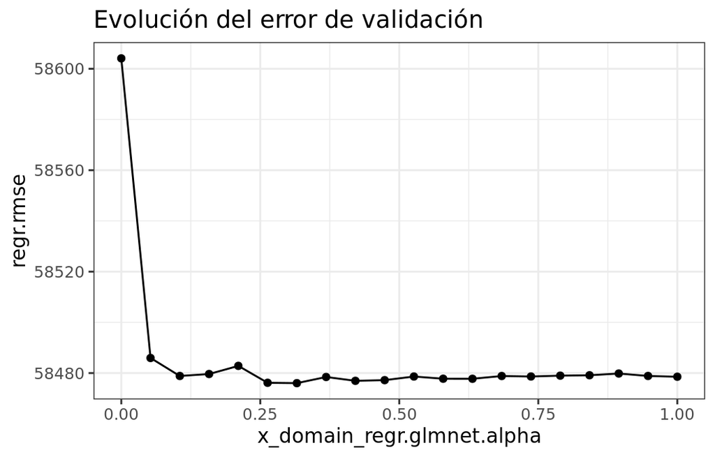

```r
ggplot(
  data = grid$archive$data(unnest = "x_domain"),
  aes(x = x_domain_regr.glmnet.alpha, y = regr.rmse)
) +
geom_point() +
geom_line() +
labs(title = "Evolución del error de validación") +
theme_bw()
```

```r
# MODELO FINAL
# =============================================================================
graph_learner$param_set$values = grid$result_learner_param_vals
graph_learner$train(task_train)
```

```r
# PREDICCIONES TEST
# =============================================================================
predicciones_test <- graph_learner$predict(task_test)
predicciones_test$score(metrica)
```

```
## regr.rmse
##  58488.96
```